# Forecasting Unemployment Rates in the U.S.

Matt K

2024-08-20

# Introduction

The goal of this project is to develop a model that can estimate unemployment rates in the U.S. using mortgage information for each state.

### Background

The data in this project comes from a variety of sources, including the Bureau of Labor Services[^1], Zillow forecasting[^2], and the Federal Housing Finance Agency[^3] mortgage datasets. The data is divided by state, chronologically from January 2000 to December 2022, containing data from monthly unemployment reports and mortgage info. Notably, this period includes the 2007-2008 financial crisis, caused in large part by a failure in the housing market to adequately protect itself, resulting in the creation and subsequent collapse of the housing bubble. A subprime mortgage is a loan written to a borrower with poor credit history - essentially, a borrower with a higher risk of defaulting on the loan than a prime borrower, someone who is deemed likely to repay their loan.

### Expectations

The COVID-19 pandemic in early 2020 led to an economic decline in the U.S., and globally, of catastrophic proportion, as some employees were laid-off in response to quarantine-guidelines to find jobs soon after, while many others were thrown into long-term unemployment. I imagine the model will do a poor job at predicting this historic period of unemployment, the greatest in the U.S. since the Great Depression, though it will hopefully predict some of the unemployment.

### Approach

# EDA

First we load in and tidy the data, then perform some preliminary analysis.

```r
# Load all packages
library("readxl")
library("data.table")
library(naniar)
library(rsample)
library(patchwork)
library(janitor)
library(tidyverse)
library(tidymodels)
library(zoo)
library(ggplot2)
library(corrplot)
library(glmnet)
library(kknn)
library(rpart.plot)
library(ranger)
library(vip)
library(xgboost)
tidymodels_prefer()
```

### Loading and Tidying Data

```r
# Read-in and assign datasets to a variable
housing_data <- read.csv("data/State Home Value - Zestimate.csv")
unemployment_data <- read.table("data/State Unemployment.txt", sep="\t", header = T)
mortgage_data <- read.csv("data/Mortgage data.csv")
# Remove comments to preview data-frames
# head(housing_data)
# Needs to be reformatted to long-form - 300 columns, shows median home value by state, monthly for the past 30 or so years
# head(unemployment_data)
# Needs reformatting, but series_id relates to a state, and value corresponds to 6 different measures of employment and will need to be tidied - unemployment rate (%), number of employed, etc.
# head(mortgage_data)
# Needs to be reformatted to wide format by series_id, and only focus on "All Mortgages (Home Purchase)" market
```

After reading in our 3 data sets, lets see where the missing data is. We can see below that housing_data is fairly complete, missing only a small portion of data, so it is easiest to simply remove those missing values.

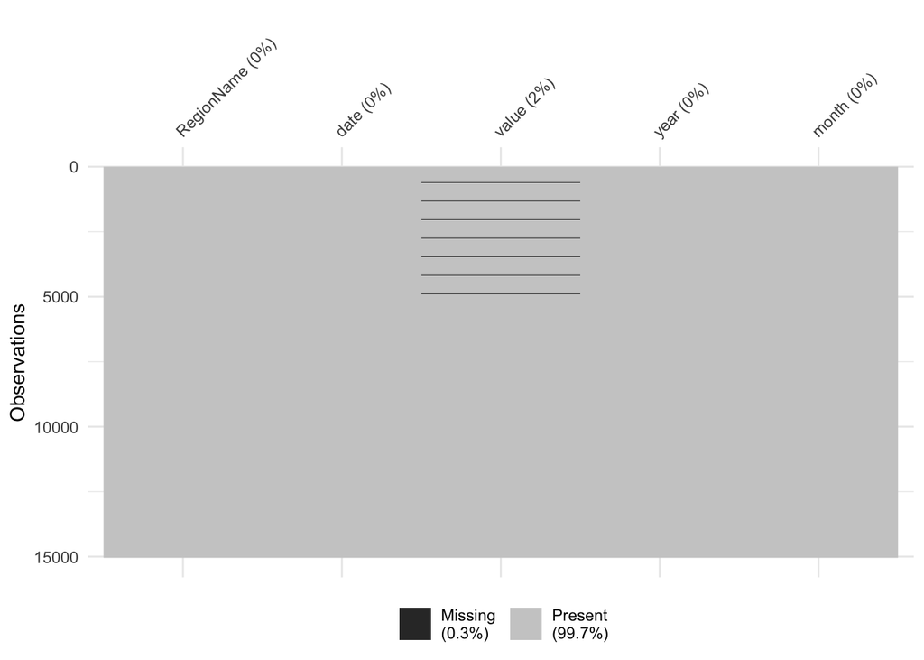

```r
# Select relevant variables and transform housing_data to long-form by State
housing_data <- subset(housing_data, select = -c(RegionID, SizeRank, RegionType, StateName))
housing_data <- melt(setDT(housing_data), id.vars = "RegionName", variable.name = "date")

# Extract year and month from date
housing_data <- housing_data %>%
  mutate(year = as.integer(str_sub(date, 2, 5)),
         month = as.integer(str_sub(date, 7, 8)))

vis_miss(housing_data) # Since missing data is fairly limited, easiest to omit missing values
```

```r
housing_data <- housing_data %>%
  select(state = RegionName, year, month, median_home_value = value) %>%
  na.omit()

# Read-in variable-code dictionary from BLS database to convert from code-named variable to named variables
statistic_map <- read.table("data/la.measure", sep = "\t", header = T)

# Read-in state-code dictionary from BLS database to convert from code-named states to named states
state_map <- read.table("data/la.state_region_division", sep = "\t", header = T)

# Extract relevant details to prepare for mapping
unemployment_data <- unemployment_data %>%
  mutate(statistic_code = as.integer(str_sub(series_id, 20)),
         state_code = as.integer(str_sub(series_id, 6, 7)), # Extract identifying codes from series_id
         month = as.integer(str_sub(period, 2, 3))) # Extract month from period variable

# Map variables and states to convert from code-names for readability
unemployment_data <- merge(unemployment_data, statistic_map, by.x = "statistic_code", by.y = "measure_code")
unemployment_data <- merge(unemployment_data, state_map, by.x = "state_code", by.y = "srd_code")

# Select relevant variables and convert data to wide-format for ease of use
unemployment_data <- unemployment_data %>%
  select(state = srd_text, measure = measure_text, year, month, value)
unemployment_data <- dcast(setDT(unemployment_data), state + year + month ~ measure, value.var = "value")
unemployment_data <- unemployment_data %>%
  mutate(across(-state, as.numeric))

# Select relevant variables and rows, i.e. "All Mortgages"
mortgage_data <- mortgage_data %>%
  filter(MARKET == "All Mortgages") %>%
  select(state = GEONAME, year = YEAR, SERIESID, VALUE1, VALUE2)

# Melt mortgage data and extract relevant variables in long-form
mortgage_data <- melt(setDT(mortgage_data), id.vars = c("state", "year", "SERIESID"), value.name = "value")
mortgage_data <- dcast(setDT(mortgage_data), state + year ~ SERIESID + variable, value.var = "value")

# Merge dataset on state, year, and month
unemp_housing <- merge(unemployment_data, housing_data, by = c("state", "year", "month"))
merged_data <- merge(unemp_housing, mortgage_data, by = c("state", "year"))
merged_data <- cbind(date = as.Date(paste(merged_data$year, merged_data$month, "01", sep = "-"), format = "%Y-%m-%d"), merged_data) # Convert date to usable format at the start of each month for consistency, i.e YYYY-MM-DD

# Order merged data by date
merged_data <- merged_data[order(as.Date(merged_data$date, format = "%Y-%m-%d"))]
merged_data <- clean_names(merged_data)
merged_data <- merged_data %>%
  select(-c(year, month, unemployment, employment, employment_population_ratio))
```

### Exploring the Data

```r
dim(merged_data)
```

```
## [1] 13848   122
```

The dataset has 13848 rows and 122 columns - this might need to be narrowed down later.

```r
missing_data <- sapply(merged_data, function(x) sum(is.na(x)))
print(paste("There are", sum(missing_data), "missing observations!"))
```

```
## [1] "There are 82848 missing observations!"
```

```r
high_na <- names(which(missing_data > 2000)) # Columns with high portions of missing data
# high_na # Running this line of code reveals the columns with missing data to be of little interest
# The variables with high amounts of missing data are also not variables of interest, and can be removed with minimal loss of info
```

Woah! That is a lot of missing data, but it is clustered in columns which appear to be of little interest so they can be removed. Let’s make sure we removed all the missing data below, then view the dimensions and preview the cleaned data.

```r
merged_data <- merged_data %>%
  select(-all_of(high_na), -ends_with("value2")) # Many columns have a value2 which does not convey much info and creates multicollinearity - these are removed
sum(is.na(merged_data))
```

```
## [1] 0
```

```r
dim(merged_data)
```

```
## [1] 13848    52
```

```r
head(merged_data)
```

| date | state | labor_force | labor_force_participation_rate | unemployment_rate | median_home_value | ave_age_borrower_value1 | ave_cltv_value1 | ave_dti_value1 | ave_intrate_value1 | ave_loanamt_value1 | ave_ltv_value1 | ave_propval_value1 | ave_term_value1 | ave_vantagescr_value1 | pct_age_2534_value1 | pct_age_3544_value1 | pct_age_4554_value1 | pct_age_5564_value1 | pct_age_ge65_value1 | pct_age_lt25_value1 | pct_arm_value1 | pct_cashout_value1 | pct_cltv_7080_value1 | pct_cltv_8090_value1 | pct_cltv_9095_value1 | pct_cltv_9597_value1 | pct_cltv_gt97_value1 | pct_cltv_le70_value1 | pct_dti_3743_value1 | … |
| --- | --- | --- | --- | --- | --- | --- | --- | --- | --- | --- | --- | --- | --- | --- | --- | --- | --- | --- | --- | --- | --- | --- | --- | --- | --- | --- | --- | --- | --- | --- |
| 2000-01-01 | Alabama | 2155396 | 64.0 | 4.7 | 100947.64 | 42 | 75 | 33.3 | 8.5 | 86 | 74 | 116 | 24 | 668 | 25.4 | 29.5 | 24.2 | 10.9 | 4.6 | 5.4 | 7.3 | 20.8 | 19.9 | 15.3 | 10.5 | 7.9 | 13.0 | 33.4 | 20.5 | … |
| 2000-01-01 | Alaska | 319633 | 73.5 | 6.2 | 135987.26 | 42 | 79 | 35.2 | 8.0 | 127 | 78 | 161 | 26 | 689 | 25.4 | 31.8 | 25.4 | 9.7 | 3.2 | 4.5 | 3.2 | 14.2 | 16.1 | 15.3 | 9.7 | 7.2 | 23.3 | 28.3 | 24.0 | … |
| 2000-01-01 | Arizona | 2497340 | 65.5 | 4.1 | 135019.05 | 43 | 78 | 34.7 | 8.4 | 117 | 77 | 154 | 27 | 676 | 24.6 | 28.7 | 23.4 | 12.4 | 5.8 | 5.1 | 11.0 | 14.2 | 21.3 | 15.5 | 11.5 | 7.8 | 15.7 | 28.2 | 21.9 | … |
| 2000-01-01 | Arkansas | 1266292 | 62.8 | 4.3 | 87671.48 | 42 | 73 | 31.0 | 8.4 | 73 | 73 | 100 | 22 | 672 | 25.7 | 27.6 | 23.2 | 11.6 | 4.8 | 7.1 | 4.5 | 16.6 | 16.7 | 14.8 | 10.2 | 5.1 | 17.7 | 35.5 | 17.3 | … |
| 2000-01-01 | California | 16664807 | 66.8 | 5.0 | 191545.84 | 43 | 74 | 35.0 | 8.3 | 182 | 73 | 252 | 27 | 681 | 25.5 | 33.0 | 23.0 | 10.8 | 4.9 | 2.7 | 19.9 | 18.3 | 24.1 | 13.2 | 7.3 | 7.6 | 10.6 | 37.1 | 22.7 | … |
| 2000-01-01 | Colorado | 2350618 | 72.7 | 2.8 | 177987.78 | 41 | 73 | 34.8 | 8.3 | 137 | 72 | 186 | 26 | 686 | 28.0 | 32.9 | 23.0 | 8.6 | 3.4 | 4.2 | 13.8 | 19.7 | 21.8 | 14.6 | 7.8 | 9.1 | 10.1 | 36.5 | 21.6 | … |

Upon removing the missing values and removing variables with excessive repetition and multicorrelation, since many variables had a value1 and value2 column reporting nearly identical information, there are still 13848 rows, but only 52 columns.

### Splitting the Data

In order to prevent data leakage, a time split is performed with a 70:30 split between the training and testing set. Let’s make sure the split is performed correctly.

```r
set.seed(158342) # Set seed for reproducibility
# Split the data with a time_split to prevent leakage
time_split <- initial_time_split(merged_data, prop = .70)
# Save the training and testing splits
split_train <- training(time_split)
split_test <- testing(time_split)
# Save a k-fold cross-validation for later with 5 folds, opting for no stratification due to time-series data - a sliding-window was considered, but voided for simplicity and poor performance
split_fold <- vfold_cv(split_train, v = 5)
# Verify that the data split correctly
nrow(split_train)/nrow(merged_data)
```

```
## [1] 0.6999567
```

```r
nrow(split_test)/nrow(merged_data)
```

```
## [1] 0.3000433
```

There is a proportion of ~70% in the training set and ~30% in the testing set, so the split operated correctly. Additionally, a k-fold cross-validation set is created using 5 folds from the training set. We perform cross-validation with 5 folds instead of 10 to save resources, and do this in order to yield better models from when tuning in order to iterate our model over more data.

```r
print(paste("There are ", sum(is.na(split_train)), " missing values left, and the training set ranges from the years ", format(min(split_train$date), "%Y"), " to ", format(max(split_train$date), "%Y"), ". There are ", nrow(split_train), " rows and ", ncol(split_train), " columns in the training set.", sep = ""))
```

```
## [1] "There are 0 missing values left, and the training set ranges from the years 2000 to 2016. There are 9693 rows and 52 columns in the training set."
```

### Exploring the Training Set

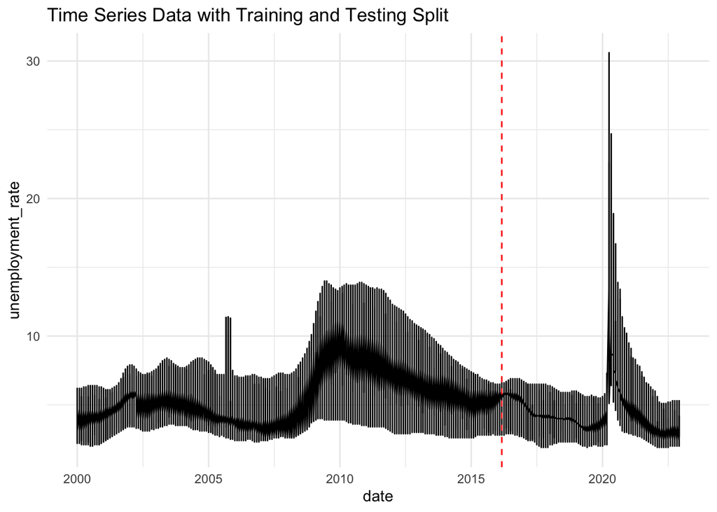

```r
ggplot(merged_data, aes(x = date, y = unemployment_rate)) +
  geom_line() +
  geom_vline(xintercept = as.numeric(max(split_train$date)), color = "red", linetype = "dashed") +
  ggtitle("Time Series Data with Training and Testing Split") +
  theme_minimal() # Plot the time-series split
```

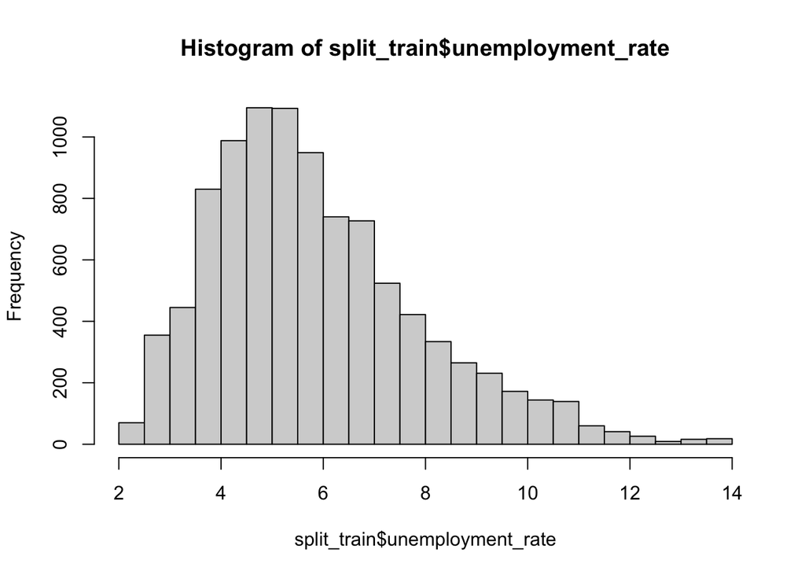

```r
hist(split_train$unemployment_rate, breaks = 25)
```

The histogram shows that unemployment across from 2000-2016 is right-skewed, tending towards ~5%, with some states experiencing short periods of high unemployment. This matches the time-series graph above, which shows a sudden increase in unemployment lasting for several years, but steadily decreasing from the peak. These sudden movements suggest that unemployment rate may be highly sensitive to news shocks, something that may not be reflected well in mortgage rates, which tend to have long-time horizons. However, this will be something to look for when modelling, as new mortgage loans are highly sensitive to economic conditions due to interest rate changes and potentially refinancing or defaulting on loans when employment and income is hard to find.

### Summaries and Correlation

Below, we can see summary statistics of the unemployment rate, with a mean greater than the median of 5.50%. The minimum unemployment rate is 2%. The highest unemployment rate is also highlighted, found in 2009 during the Great Recession.

```r
summary(split_train$unemployment_rate)
```

```
##    Min. 1st Qu.  Median    Mean 3rd Qu.    Max.
##   2.000   4.400   5.500   5.911   7.000  14.000
```

```r
split_train[which.max(split_train$unemployment_rate)]
```

| date | state | labor_force | labor_force_participation_rate | unemployment_rate | median_home_value | ave_age_borrower_value1 | ave_cltv_value1 | ave_dti_value1 | ave_intrate_value1 | ave_loanamt_value1 | ave_ltv_value1 | ave_propval_value1 | ave_term_value1 | ave_vantagescr_value1 | pct_age_2534_value1 | pct_age_3544_value1 | pct_age_4554_value1 | pct_age_5564_value1 | pct_age_ge65_value1 | pct_age_lt25_value1 | pct_arm_value1 | pct_cashout_value1 | pct_cltv_7080_value1 | pct_cltv_8090_value1 | pct_cltv_9095_value1 | pct_cltv_9597_value1 | pct_cltv_gt97_value1 | pct_cltv_le70_value1 | pct_dti_3743_value1 | … |
| --- | --- | --- | --- | --- | --- | --- | --- | --- | --- | --- | --- | --- | --- | --- | --- | --- | --- | --- | --- | --- | --- | --- | --- | --- | --- | --- | --- | --- | --- | --- |
| 2009-06-01 | Michigan | 4905950 | 63.2 | 14 | 111557.5 | 45 | 77 | 34.2 | 5.2 | 144 | 76 | 201 | 26 | 736 | 20.9 | 24.5 | 25.7 | 17 | 7.7 | 4.2 | 1.2 | 21 | 26.1 | 9.9 | 6.7 | 12.7 | 12.8 | 31.9 | 17.6 | … |

The unemployment rate in the training set reached a maximum in 2009, in the state of Michigan, at 14%. This spike is seen throughout the training set, due largely to the Great Recession.

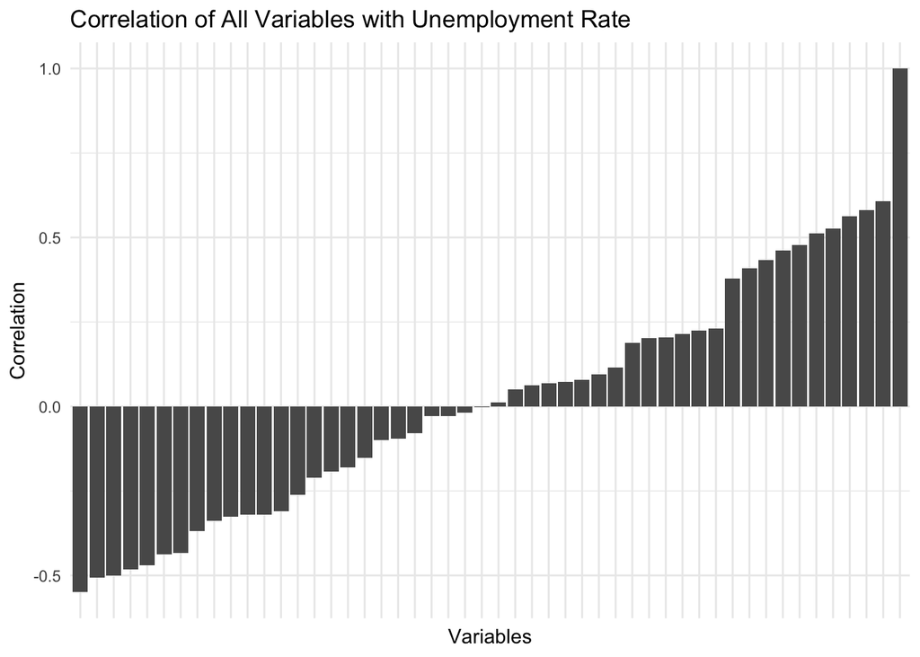

```r
# Select numeric columns by name, calculate the correlation of each with respect to unemployment_rate
numeric <- sapply(split_train, is.numeric)
numeric <- names(split_train)[numeric]
corr_mat <- sapply(numeric, function(x) cor(split_train[[x]], split_train$unemployment_rate))
corr_mat <- data.frame(Var = numeric, Correlation = corr_mat) # Convert to a data-frame for plotting
# Plot ordered correlations in increasing order
ggplot(corr_mat, aes(x = reorder(Var, Correlation), y = Correlation)) +
  geom_bar(stat = "identity") +
  labs(title = "Correlation of All Variables with Unemployment Rate",
       x = "Variables") +
  theme_minimal() +
  theme(axis.text.x = element_blank()) # Remove variable names from x-axis for readability
```

There appears to be a fair number of moderately correlated variables with the outcome variable, as shown by the moderate number of predictors around -0.5 and 0.5 correlation. There also appear to be a fair number of uncorrelated variables, which could be dealt with via feature selection.

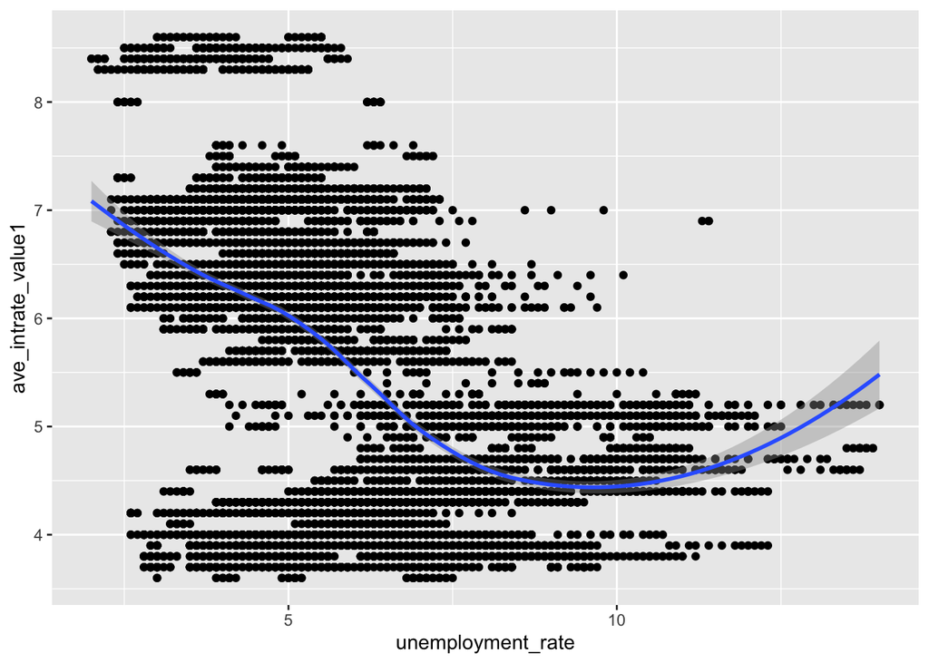

```r
# Graph unemployment_rate against variable of choice (here, ave_intrate_value1), reveals potential non-linear relationships
ggplot(split_train, aes(x = unemployment_rate, y = ave_intrate_value1, y ~ x)) +
  geom_point() +
  geom_smooth(formula = y ~ x, method = "loess")
```

It appears as if some variables have a non-linear relationship with unemployment rate, as seen above, where average interest rate is shown on the y axis and a curved line-of-best fit shows a parabolic shape. The data will be used as is, though this is something to keep in mind if there is poor performance in the models.

# Recipe Creation

Here, two recipes are created - one, unemp_recipe, by removing the factors and then normalizing all predictors, while the other, PCA_recipe, includes a principal component analysis keeping 10 components. Two recipes are created to examine interpretability as well as complexity.

```r
unemp_recipe <- recipe(unemployment_rate ~ ., data = split_train) %>%
  step_rm(date, state) %>%
  step_normalize(all_predictors())

prep(unemp_recipe) %>%
  bake(new_data = split_train)

PCA_recipe <- recipe(unemployment_rate ~ ., data = split_train) %>%
  step_rm(date, state) %>%
  step_normalize(all_predictors()) %>%
  step_pca(all_predictors(), num_comp = 10)

prep(PCA_recipe) %>%
  bake(new_data = split_train)
```

# Models

Each of the models followed a similar build, with slight differences in the implementation of each - the recipe for each was decided by performance and computation costs, so PCA_recipe was used for more computationally intensive models. Each model was tuned where possible, then fit with a grid of varying levels (dependent again upon computation costs). Finally, each model was fit and evaluated on the training set on their RMSE, though in order to avoid over-fitting, the exact implementation of this varies, and is detailed in each respective model’s description. The results of the models are compared after all the models are set-up. ### Elastic Net Model Tuning the mixture and penalty hyperparemeters with 10 levels, the results are shown below. The ranges for tuning mixture are 0-1 and also 0-1 for penalty.

```r
# Set up the model and the workflow, with the unemp_recipe since this model does not require much computing power
elastic_net_model <- linear_reg(mixture = tune(),
                                penalty = tune()) %>%
  set_mode("regression") %>%
  set_engine("glmnet")
elastic_net_workflow <- workflow() %>%
  add_recipe(unemp_recipe) %>%
  add_model(elastic_net_model)
```

```r
# Create a tuning grid for the elastic_net model, with penalty and mixture values to try and 10 levels
elastic_net_grid <- grid_regular(penalty(range = c(0, 1),
                                         trans = identity_trans()),
                                 mixture(range = c(0, 1)),
                                 levels = 10)
```

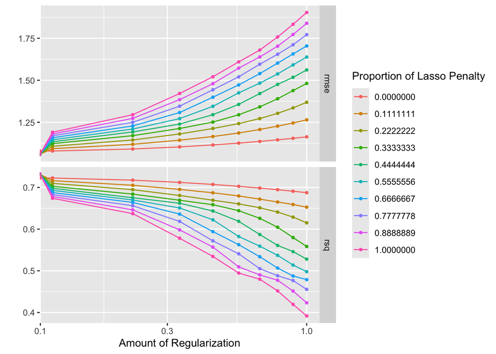

```r
# The tuning results are computed and plotted
tune_results <- tune_grid(
  elastic_net_workflow,
  resamples = split_fold,
  grid = elastic_net_grid
  )
autoplot(tune_results)
```

The tuning results of the elastic net model show low regularization performs best - the R-squared values show that the model did not perform as well as it could have, though the RMSE is fairly low for all models. This could be a good sign that the model did not overfit to the training set, something that may be prone to happen due to the specificity of this data as well as the vast number of features.

```r
# Opt to use one_std_error selection here due to close proximity of each models, select least complex
best_en_model <- select_by_one_std_err(tune_results,
                          metric = "rmse",
                          penalty,
                          mixture)
# Finalize optimal workflow with tuning results
elastic_net_final <- finalize_workflow(elastic_net_workflow,
                                       best_en_model)
# Fit the workflow to the training data
elastic_fit <- fit(elastic_net_final,
                   data = split_train)
# Predict values with the training data
elastic_pred <- predict(elastic_fit, new_data = split_train  %>%
                               select(-unemployment_rate))
# Bind true unemployment_rate as well as date, state for plotting purposes
elastic_pred <- bind_cols(elastic_pred, split_train %>% select(unemployment_rate, state, date))
```

### k-Nearest Neighbors model

```r
knn_model <- nearest_neighbor(neighbors = tune()) %>%
  set_engine("kknn") %>%
  set_mode("regression")

knn_workflow <- workflow() %>%
  add_model(knn_model) %>%
  add_recipe(PCA_recipe) # Use PCA_recipe instead of unemp_recipe to avoid overfitting
# Set-up tuning grid with 10 levels, from 1-250 neighbors
knn_grid <- grid_regular(
  neighbors(range = c(1, 250)),
            levels = 10)
```

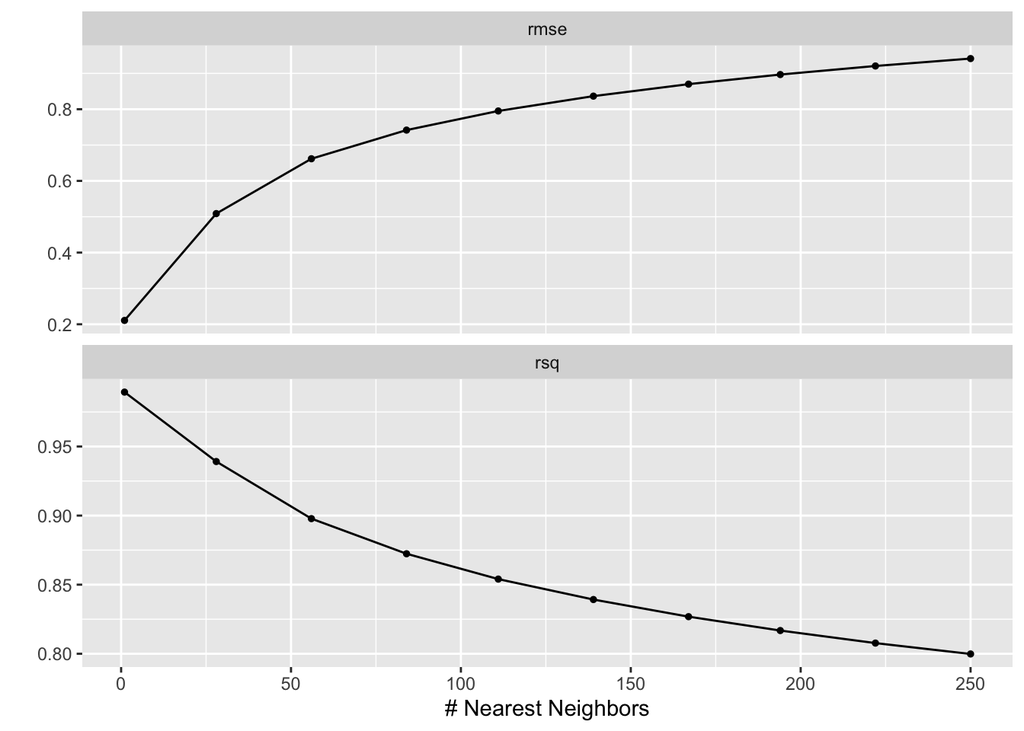

```r
tune_results_knn <- tune_grid(
  knn_workflow,
  resamples = split_fold,
  grid = knn_grid
)
autoplot(tune_results_knn)
```

The tuning results for the KNN model show that as the number of neighbors increases, R-squared decreases and RMSE increases slowly. However, with a low number of nearest neighbors, the R-squared is extremely high. As such, it is highly likely that overfitting is occuring at this point, and since there is fairly minimal losses with more neighbors, the best model is selected with a 15% allowable loss in the R-squared to avoid over-fitting to the training set.

```r
# Allow 15% loss to R-squared in order to prevent over-fitting to training set
best_knn_model <- select_by_pct_loss(tune_results_knn,
                                     metric = "rsq",
                                     limit = 15,
                                     desc(neighbors)
                                     )
# Finalize workflow with optimal tuned model
knn_final <- finalize_workflow(knn_workflow, best_knn_model)
# Fit model and predict unemployment_rate
knn_fit <- fit(knn_final, split_train)
knn_pred <- predict(knn_fit, split_train)
# Bind true unemployment_rate as well as date, state for plotting purposes
knn_pred <- bind_cols(knn_pred, split_train %>%
                        select(date, state, unemployment_rate))
```

### Linear Model

```r
# Set up the model, workflow with PCA_recipe, then fit and predict values
lm_model <- linear_reg() %>%
  set_engine("lm")
lm_workflow <- workflow() %>%
  add_model(lm_model) %>%
  add_recipe(PCA_recipe)
# Fit model and predict unemployment_rate
lm_fit <- fit(lm_workflow, split_train)
lm_pred <- predict(lm_fit, new_data = split_train)
# Bind true unemployment_rate as well as date, state for plotting purposes
lm_pred <- bind_cols(lm_pred, split_train %>%
                             select(state, date, unemployment_rate))
```

### Pruned Decision Tree

A decision tree is tuned for cost_complexity with the PCA_recipe for performance improvements, with 10 levels. The performance of each model is graphed below. The ranges for tuning cost_complexity are 0.001 to 0.1 with 10 levels. The results are plotted below.

```r
# Process is nearly identical to previous models
tree_model <- decision_tree(cost_complexity = tune()) %>%
  set_engine("rpart") %>%
  set_mode("regression")

tree_workflow <- workflow() %>%
  add_model(tree_model) %>%
  add_recipe(PCA_recipe)

tree_grid <- grid_regular(
  cost_complexity(range = c(-3, -1)), # Tune cost_complexity on a log-scale, so -3 ->10^-3 and -1 -> 10^-1
  levels = 10
)
```

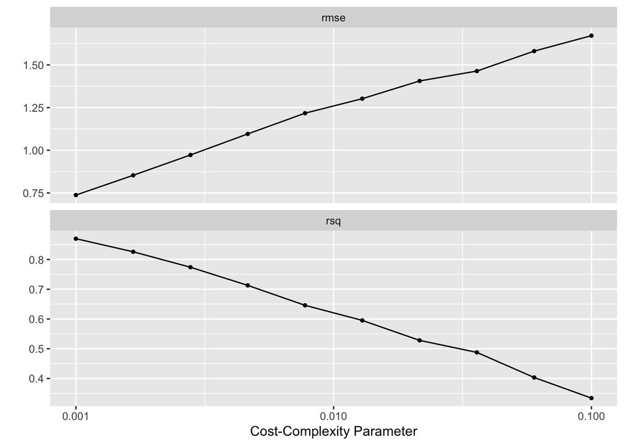

```r
# Collect results from tune and plot
tune_results_tree <- tune_grid(
  tree_workflow,
  resamples = split_fold,
  grid = tree_grid)

autoplot(tune_results_tree)
```

The performance of the model is best at low cost-complexity, with a fairly linear and significant drop in performance. The best model is selected using a 10% acceptable loss in the R-square metric to avoid overfitting.

```r
# Avoid overfitting with 10% acceptable loss in R^squared metric
tree_best <- select_by_pct_loss(tune_results_tree,
                                metric = "rsq",
                                limit = 10,
                                desc(cost_complexity)
                                )
# Finalize workflow with optimal model
tree_final <- finalize_workflow(tree_workflow, tree_best)
# Fit and predict values on training set
tree_fit <- fit(tree_final, data = split_train)
tree_pred <- predict(tree_fit, new_data = split_train %>%
                       select(-unemployment_rate))
# Bind true unemployment_rate as well as date, state for plotting purposes
tree_pred <- bind_cols(tree_pred, split_train %>%
                         select(date, state, unemployment_rate))
```

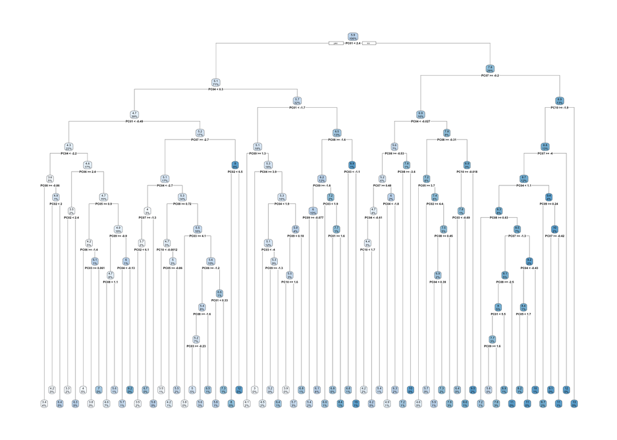

```r
# View the decision tree
tree_fit %>%
  extract_fit_engine() %>%
  rpart.plot(roundint = F)
```

Due to the use of PCA and a low cost-complexity, the pruned decision tree is difficult to interpret. Regardless, it can be seen that a value of 2.4 is the cut-off for PC_01, and the tree can be followed as deeply as desired.

### Random Forest Model

A random forest model is tuned on mtry, trees, and min_n with the PCA_recipe due to computational costs. The range of mtry is 1-9 due to complexity and PCA bounded at 10 variables, while trees goes from 101-501 for complexity costs and min_n ranges from 5-15, and there are 4 levels, again for computational reasons. Furthermore, the model is saved as forest_res.rda and loaded in to avoid having to re-run the model due to long run-times.

```r
set.seed(135) # Set seed for reproducibility due to random nature of random forests
forest_model <- rand_forest(mtry = tune(),
                            trees = tune(),
                            min_n = tune()) %>%
  set_engine("ranger", importance = "impurity") %>%
  set_mode("regression")
forest_workflow <- workflow() %>%
  add_model(forest_model) %>%
  add_recipe(PCA_recipe) # Selected over unemp_recipe to minimize run-time
forest_grid <- grid_regular(mtry(range = c(1, 9)), # 1-9 selected due to limited PCA variables
                            trees(range = c(101, 501)), # Selected to limit complexity
                            min_n(range = c(5, 15)),
                            levels = 4)
```

```r
# eval = FALSE to avoid re-running costly model, instead save file and load back in later
forest_tune_res <- tune_grid(
  forest_workflow,
  grid = forest_grid,
  resamples = split_fold
)
save(forest_tune_res, file = "forest_res.rda") # save file
```

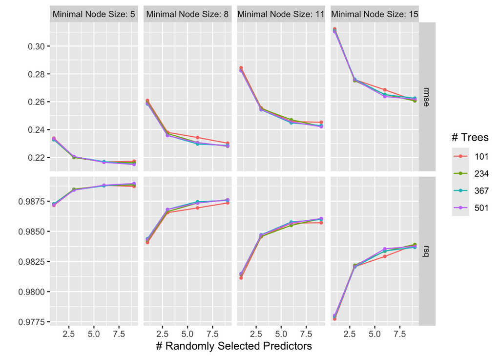

```r
load("forest_res.rda") # load file
autoplot(forest_tune_res)
```

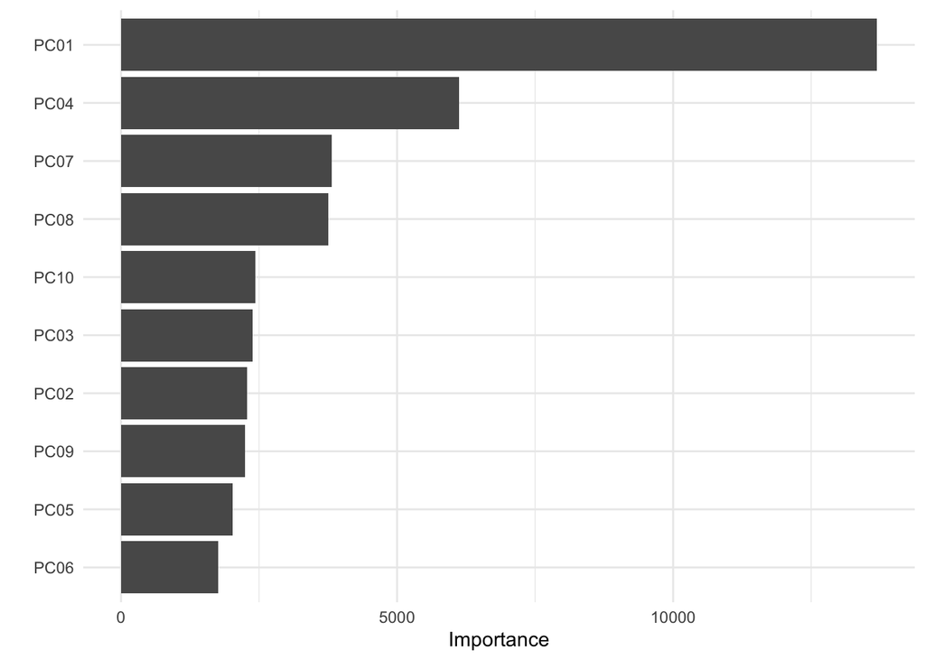

```r
# Select by one_std_err on RMSE to avoid overly complex model
best_forest <- select_by_one_std_err(forest_tune_res, metric = 'rmse', trees)

forest_final <- finalize_workflow(forest_workflow, best_forest)
forest_fit <- fit(forest_final, data = split_train)
# Variable Importance Plot to show most/least important components
forest_fit %>% extract_fit_parsnip() %>%
  vip() + theme_minimal()
```

```r
# Predict unemployment rates from training set
forest_pred <- predict(forest_fit, split_train %>%
                         select(-unemployment_rate))
# Bind true unemployment_rate as well as date, state for plotting purposes
forest_pred <- bind_cols(forest_pred, split_train %>%
                           select(date, state, unemployment_rate))
```

### Boosted Tree Model

A boosted tree model, set up similar to the random forest with one key difference - instead of tuning for min_n, we tune for learn_rate, deemed more significant in the performance of boosted tree models. For similar reasons as the random forest, the results of tuning are saved in a separate file and loaded in. The ranges for tuning are mtry from 1-11, trees from 501-1301, and learn_rate from 0.00000001-0.1 with 6 levels. The results of tuning are graphed below.

```r
set.seed(513) # Set seed for reproducibility
boosted_model <- boost_tree(mtry = tune(),
                            trees = tune(),
                            learn_rate = tune()) %>%
  set_engine("xgboost") %>% # importance = "impurity", removed for knitting
  set_mode("regression")
boosted_workflow <- workflow() %>%
  add_model(boosted_model) %>%
  add_recipe(PCA_recipe)
boosted_grid <- grid_regular(mtry(range = c(1, 11)),
                             trees(range = c(501, 1301)), # Tune from 501-1301
                             learn_rate(range = c(.00000001, .1), # Tune from very low learn_rate to .1
                                        trans = identity_trans()),
                             levels = 6)
```

```r
boosted_tune_res <- tune_grid(
  boosted_workflow,
  grid = boosted_grid,
  resamples = split_fold
)
save(boosted_tune_res, file = "boosted_res.rda")
```

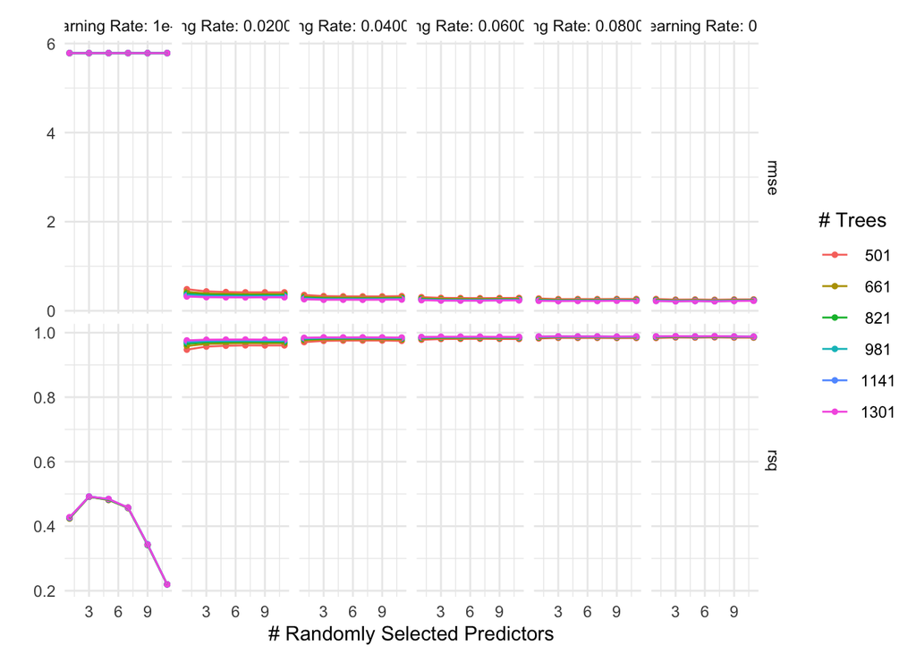

```r
load("boosted_res.rda")
autoplot(boosted_tune_res) + theme_minimal()
```

The tuning results show that the lowest learning rate performs much worse, but then there is little improvement among the other models. Furthermore, the number of trees appears negligible, and the model performance increases marginally with the number of randomly selected predictors. As such, one_std_err selection is used on RMSE to limit complexity, even though it appears overfitting will still occur.

```r
# Select by one_std_err by RMSE on learn_rate to limit complexity of model
best_boosted <- select_by_one_std_err(boosted_tune_res,
                            metric = "rmse",
                            learn_rate)
# Finalize workflow with optimal tuning info
boosted_final <- finalize_workflow(boosted_workflow, best_boosted)
# Fit model to training set and predict unemployment rates
boosted_fit <- fit(boosted_final, data = split_train)
boosted_pred <- predict(boosted_fit, new_data = split_train %>%
                          select(-unemployment_rate))
# Bind true unemployment_rate as well as date, state for plotting purposes
boosted_pred <- bind_cols(boosted_pred, split_train %>%
                            select(date, state, unemployment_rate))
```

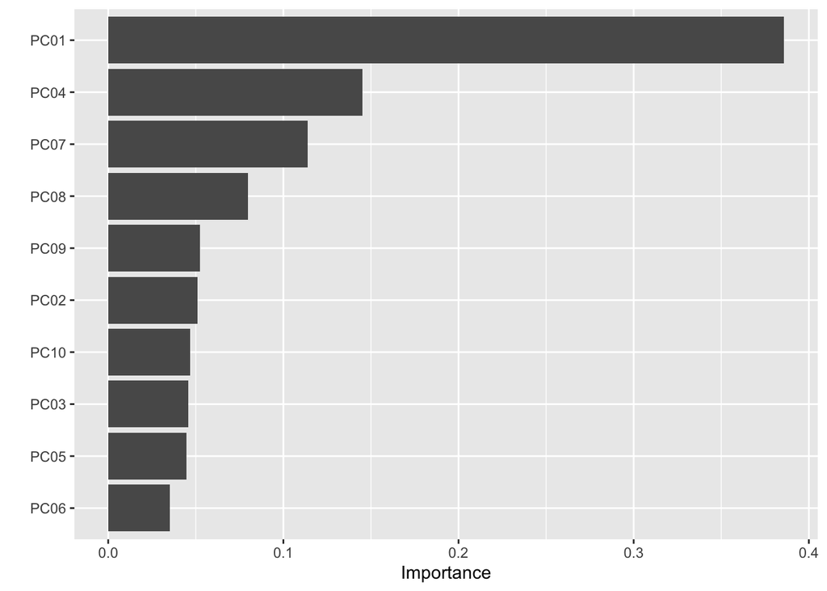

```r
boosted_fit %>%
  extract_fit_parsnip() %>%
  vip() # Variable importance plot
```

The variable importance plot shows similar results to the VIP of the random forest, with PC_01 ranked the most important component in the model, as expected due to how PCA operates - collecting the most information in the first component, and so on.

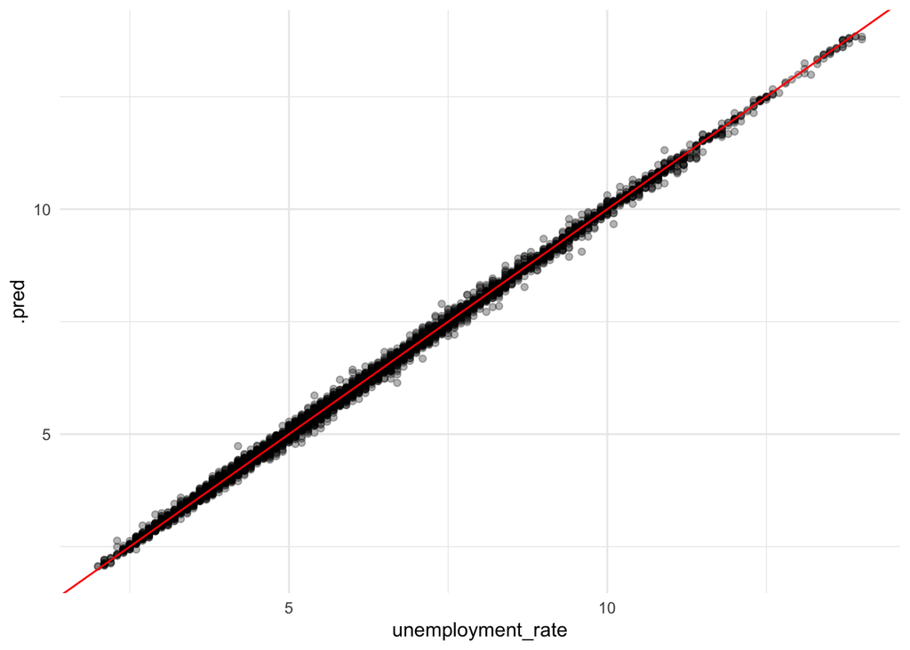

```r
# Plot predicted values versus true values
boosted_pred %>%
  ggplot(aes(x = unemployment_rate, y = .pred)) +
  geom_point(alpha = .3) +
  #scale_y_continuous(limits = c(2, 8)) +
  #scale_x_continuous(limits = c(2, 15)) +
  geom_abline(intercept = 0, slope = 1, color = "red") +
  theme_minimal()
```

This graph shows predicted unemployment rates against the observed unemployment rates, with the red line showing a perfect predictor. Clearly, the model predicts unemployment rate well on the training set, but this might be a sign of overfitting due to how little variance there is.

# Evaluating Model Performance

The chunk below creates a function with 2 inputs, state_plot(model_name, state_name), for plotting a model’s predicted unemployment rate versus the actual unemployment rate across time, by state.

```r
# Function to plot a model's predicted unemployment_rate vs the actual value, by state
state_plot <- function(model_name, state_name, title_plot) {
  state_data <- model_name %>%
    filter(state == state_name)
  ggplot(state_data, aes(x = date)) +
    geom_line(aes(y = unemployment_rate), color = "black") +
    geom_line(aes(y = .pred), color = "red") +
    labs(title = title_plot) +
    theme_minimal()
}
```

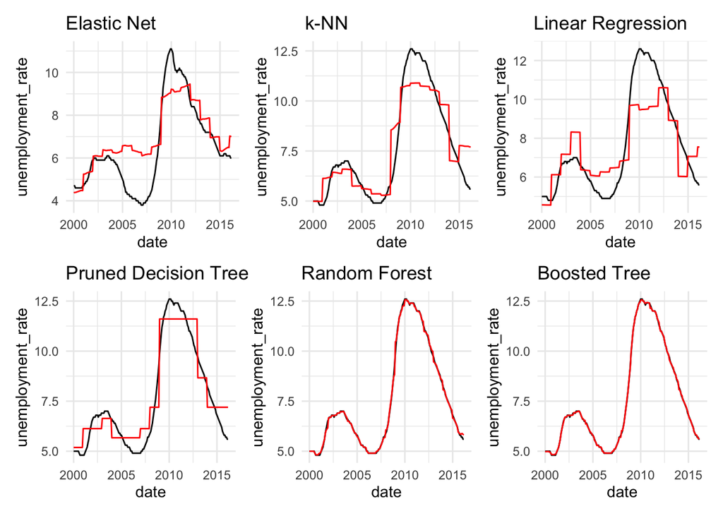

```r
metrics <- metric_set(rsq, rmse, mae) # Metrics for the regression models

# Examine the performance of the final elastic net model
en_rmse <- metrics(elastic_pred, truth = unemployment_rate, estimate = .pred)$.estimate[2]
en_plot <- state_plot(elastic_pred, "Alabama", "Elastic Net")

# Examine the performance of the final KNN model
knn_rmse <- metrics(knn_pred, truth = unemployment_rate, estimate = .pred)$.estimate[2]
knn_plot <- state_plot(knn_pred, "California", "k-NN")

# Examine the performance of the linear regression
lm_rmse <- metrics(lm_pred, truth = unemployment_rate, estimate = .pred)$.estimate[2]
lm_plot <- state_plot(lm_pred, "California", "Linear Regression")


# Examine the performance of the pruned decision tree model
dt_rmse <- metrics(tree_pred, truth = unemployment_rate, estimate = .pred)$.estimate[2]
dt_plot <- state_plot(tree_pred, "California", "Pruned Decision Tree")

# Examine the performance of the random forest model
rf_rmse <- metrics(forest_pred, truth = unemployment_rate, estimate = .pred)$.estimate[2]
rf_plot <- state_plot(forest_pred, "California", "Random Forest")

# Examine the results of the boosted tree model
bt_rmse <- metrics(boosted_pred, truth = unemployment_rate, estimate = .pred)$.estimate[2]
bt_plot <- state_plot(boosted_pred, "California", "Boosted Tree")

# Plot the California state unemployment rates for each model
model_plots <- (en_plot | knn_plot | lm_plot) /
  (dt_plot | rf_plot | bt_plot)
plot(model_plots)
```

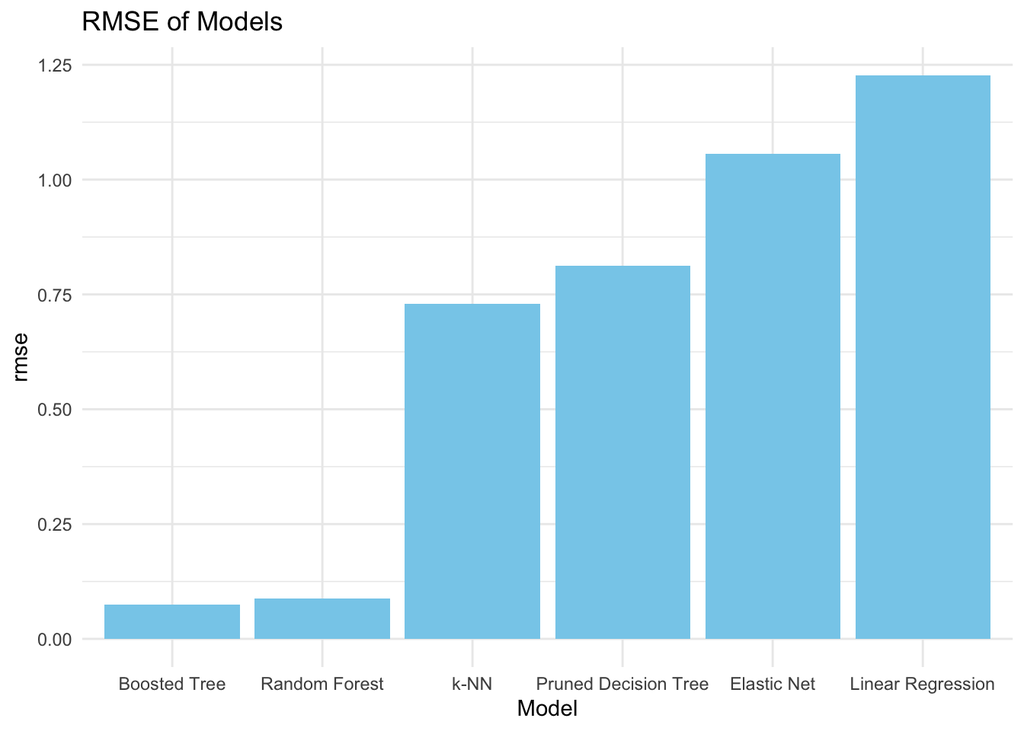

```r
# Combine results into a dataframe for graphing and compare results
model_rmse <- data.frame(model = c("Elastic Net", "k-NN", "Linear Regression", "Pruned Decision Tree", "Random Forest", "Boosted Tree"), rmse = c(en_rmse, knn_rmse, lm_rmse, dt_rmse, rf_rmse, bt_rmse))
ggplot(model_rmse, aes(x = reorder(model, rmse), y = rmse)) +
  geom_bar(stat = "identity", fill = "skyblue") +
  labs(title = "RMSE of Models", x = "Model") +
  theme_minimal()
```

This plot shows the RMSE of each model in ascending order, with boosted tree performing the best (but appearing to overfit the data in the first plot). Therefore, the boosted tree will be fit to the testing data, as will a model that appears to capture the general direction of unemployment without matching too closely - the elastic net model. The elastic net is an appealing choice since it appears to fit the overall trends in the training set without matching it too closely, suggesting that it is able to capture the movements in unemployment without overfitting. That being said, it does miss by quite a bit on the downtrend during 2005-2007, but it captures the increase during the Great Recession and subsequent decline well - it is possible that conditions during the lead-up to the subprime mortgage crisis led to mortgage data that was a poor predictor of unemployment rate because the data did not accurately reflect the status of the economy.

# Testing Performance

```r
# Use Elastic Net model to predict values for testing set and evaluate performance
elastic_test <- predict(elastic_fit, new_data = split_test  %>%
                               select(-unemployment_rate))
# Bind true unemployment_rate as well as date, state for plotting purposes
elastic_test <- bind_cols(elastic_test, split_test %>% select(unemployment_rate, state, date))

# Elastic Net Model metrics
metrics(elastic_test, truth = unemployment_rate, estimate = .pred)
```

| .metric | .estimator | .estimate |
| --- | --- | --- |
| rsq | standard | 0.2874033 |
| rmse | standard | 1.8734663 |
| mae | standard | 1.2823109 |

```r
# Use Boosted Tree model to predict values for testing set and evaluate performance
boosted_test <- predict(boosted_fit, new_data = split_test %>%
                          select(-unemployment_rate))
boosted_test <- bind_cols(boosted_test, split_test %>%
                            select(date, state, unemployment_rate))
# Boosted Tree Model metrics
metrics(boosted_test, truth = unemployment_rate, estimate = .pred)
```

| .metric | .estimator | .estimate |
| --- | --- | --- |
| rsq | standard | 0.2638173 |
| rmse | standard | 2.0625887 |
| mae | standard | 1.4804975 |

The boosted tree model performed much worse on the testing set than on the training set, with an R-squared of .264 and RMSE of 2.063. This is worse than the elastic net model, suggesting that the boosted tree had overfitting.

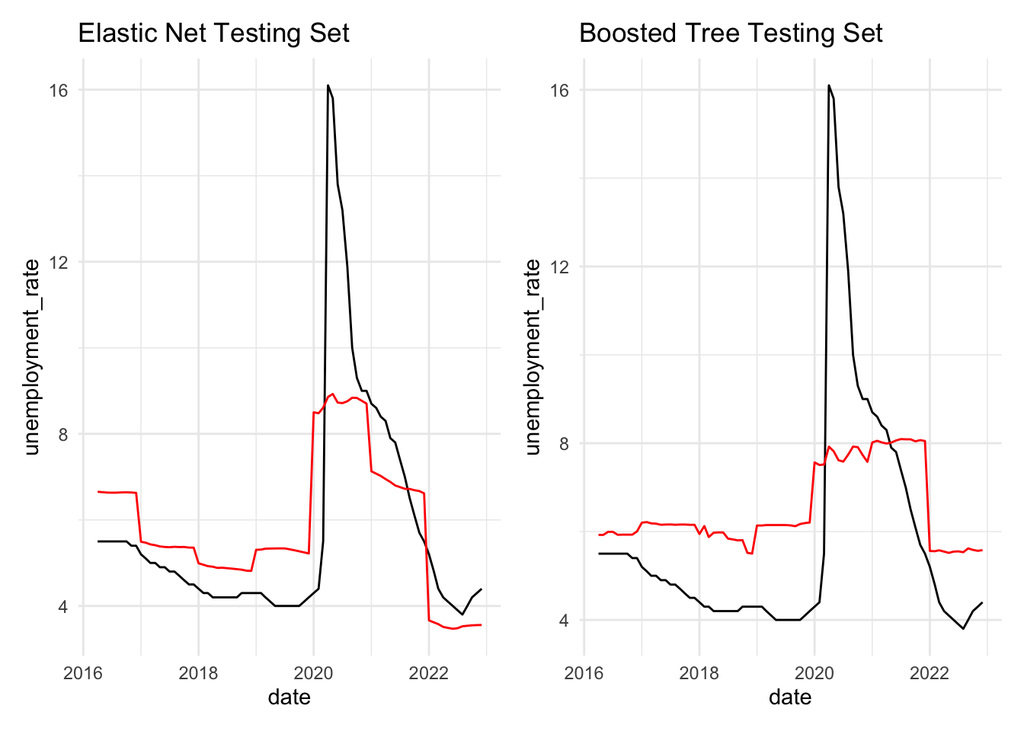

```r
# Plot model performance on testing set
enn_test_plot <- state_plot(elastic_test, "California", "Elastic Net Testing Set")
boosted_test_plot <- state_plot(boosted_test, "California", "Boosted Tree Testing Set")

plot(enn_test_plot | boosted_test_plot)
```

# Conclusion

After fitting and analyzing various models, the best performing model by RMSE was determing to be the Boosted Tree model, and a less well-fit model was selected as the Elastic Net model, for how it appeared to fit the training set generally without such a tight fit to avoid overfitting. Upon evaluating the elastic net and boosted tree models on the testing set, it appears as if the elastic net model does a better job at detecting changes in direction of unemployment rates, as seen in the plot of predicted vs observed unemployment rates above, where the boosted tree model is not flexible enough to predict shifts.

The linear regression performed the worst on the training set, though in the end an elastic net model seemed to outperform the boosted tree on the testing set, and it is possible that a linear model would similarly outperform due to being a more generalizable model. The overfitting of the boosted tree and random forest models also suggests a reason to pursue extra steps to avoid this overfitting, though it may be difficult due to the complexity of the data.

The presence of the Great Recession and the COVID-19 Pandemic in the dataset creates important factors to consider outside of these models. Regulatory changes to mortgages, security-writing, and investing may impact the broader market and thus unemployment rates, for which there may not be sufficient data at the moment, and for which old data may not be a good predictor. Furthermore, both of these economic downturns highlight the need to factor in news shocks into the model, since the model is unable to capture the extent of the sharp rise in unemployment rates. However, considering the limitations of the model, the mortgage data captures a fair amount of variation and the elastic net model performs well at matching direction changes of unemployment rates, even if it doesn’t capture the full extent of the shift.

Overall, this project was a valuable learning experience - creating the models and analyzing the results helped me learn to interpret and respond to data to develop a more accurate model, and I am happy with the results - the model seems to reflect the general trends of unemployment rates, and exceeded my expectations. I didn’t expect mortgage data to reflect the impact of the COVID-19 pandemic in the predicted unemployment rate so quickly, but there appears to be little to no lag in the response, suggesting that mortgages respond to economic conditions quickly.

# Sources

The unemployment data was provided by the [Bureau of Labor Services](https://download.bls.gov/pub/time.series/la/), accessed on August 9th, 2024.

Home values were taken from the [Zillow Home Value Index](https://www.zillow.com/research/data/), using all homes, by state, accessed on August 10th, 2024.

New Residential Mortgage monthly data was taken from the [National Mortgage Database](https://www.fhfa.gov/data/national-mortgage-database-aggregate-statistics), provided by the Federal Housing Finance Agency, accessed on August 11th, 2024.

[^1]: https://download.bls.gov/pub/time.series/la/
[^2]: https://www.zillow.com/research/data/
[^3]: https://www.fhfa.gov/data/national-mortgage-database-aggregate-statistics